# Teilnehmerzahlen

Landesebene

Teilnehmerzahl

zeitlich

Autor:innen

Zugehörigkeit

Toni Wöhrl

Universität Erfurt

Florian Bähr

Universität Erfurt

Veröffentlichungsdatum

9. März 2023

Geändert

18. September 2026

Zusammenfassung

Diese Seite zeigt die Zahl der pro Schuljahr im Bewegungs-Check des Programms „BEWEGTE KINDER = GESÜNDERE KINDER“ (BeKiGeKi) erfassten Fälle sowie die anhand der Schulstatistik Thüringen auf Schulebene aufgelöste Zahl potenziell erreichbarer Drittklässler. Als erfasst gilt ein Fall, wenn zum Auswertungszeitpunkt mindestens ein dokumentierter motorischer Testwert sowie Angaben zu Geschlecht und Alter vorliegen; auch unplausible Angaben werden dabei mitgezählt.

# Teilnahme am Bewegungs-Check

Die Auswertung unterscheidet zwischen **möglichen Teilnehmern** und **erfassten Fällen**. Mögliche Teilnehmer sind die potenziell erreichbaren Drittklässler im jeweiligen Schuljahr. Ihre Zahl wird aus den Angaben der [Schulstatistik Thüringen](https://www.schulstatistik-thueringen.de/) über alle dort aufgeführten Schulen aufsummiert, für die mindestens eine Primarschülerzahl ausgewiesen ist.

Weicht die in der Schulstatistik ausgewiesene Zahl der Drittklässler von der von einer Schule im Rahmen des BeKiGeKi-Bewegungs-Checks selbst berichteten Klassenstufenzahl ab, wird die selbst berichtete Klassenstufenzahl verwendet. Diese Priorisierung berücksichtigt, dass der Stichtag der Schulstatistik zeitlich vor dem jeweiligen Bewegungs-Check liegt und sich Klassenstärken zwischen Stichtag und Testdurchführung verändern können.

Die Darstellung verwendet den Begriff **Fall** bewusst: Ein Fall entspricht in der Regel einem Drittklässler in einem bestimmten Schuljahr bzw. zu einem bestimmten Messzeitpunkt. Wegen der anonymisierten Datenbasis kann dieselbe Person bei einer Wiederholung der dritten Klasse in mehreren Schuljahren als mehrere Fälle auftreten. Eine jahrgangsübergreifend eindeutige Zahl unterschiedlicher Personen ist daher nicht bestimmbar.

Ein **erfasster Fall mit dokumentiertem Messwert** (vgl. [Glossar](https://bekigeki.github.io/glossar.html)) liegt vor, wenn Angaben zu den Kerndaten vorhanden sind und mindestens ein motorischer Testwert dokumentiert wurde. Diese Definition bezieht sich auf die dokumentierten Daten: Sie ist nicht mit der Zahl aller tatsächlich gemessenen [Personen] gleichzusetzen, weil z.B. Messungen nicht übermittelt worden sein können.

## Kinder

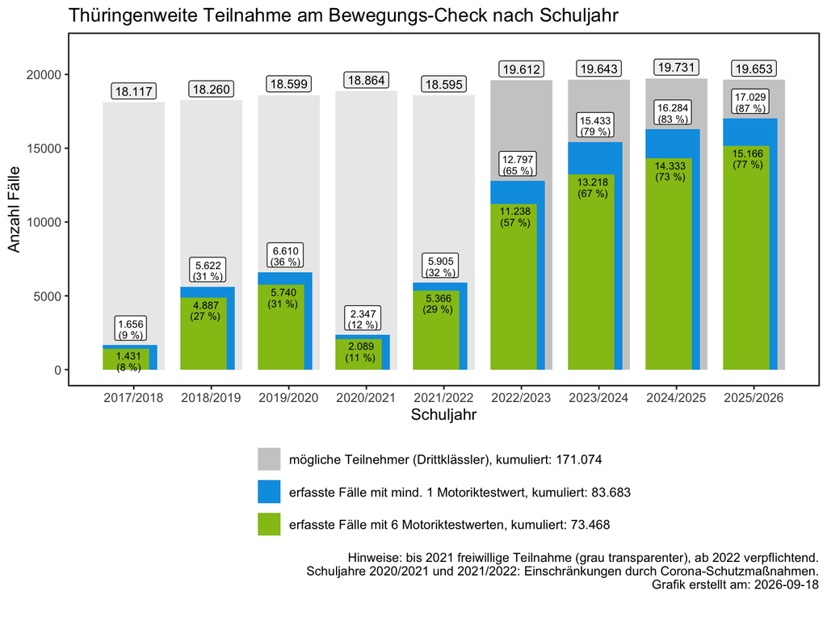

Abbildung 1: Mögliche und erfasste Fälle im BeKiGeKi-Bewegungs-Check nach Schuljahr. Grau zeigt die anhand des auf Schulebene aufgelösten Referenzwerts geschätzte Zahl möglicher Drittklässler. Blau zeigt erfasste Fälle mit Kerndaten und mindestens einem dokumentierten motorischen Testwert; Grün zeigt darunter Fälle mit sechs dokumentierten Testwerten.

Die grauen Balken sind bis einschließlich des Schuljahres 2021/2022 transparenter dargestellt. Sie markieren die Phase freiwilliger Teilnahme; ab dem Schuljahr 2022/2023 ist die Teilnahme verpflichtend. Die Schuljahre 2020/2021 und 2021/2022 waren durch Corona-Schutzmaßnahmen eingeschränkt.

## Schulen

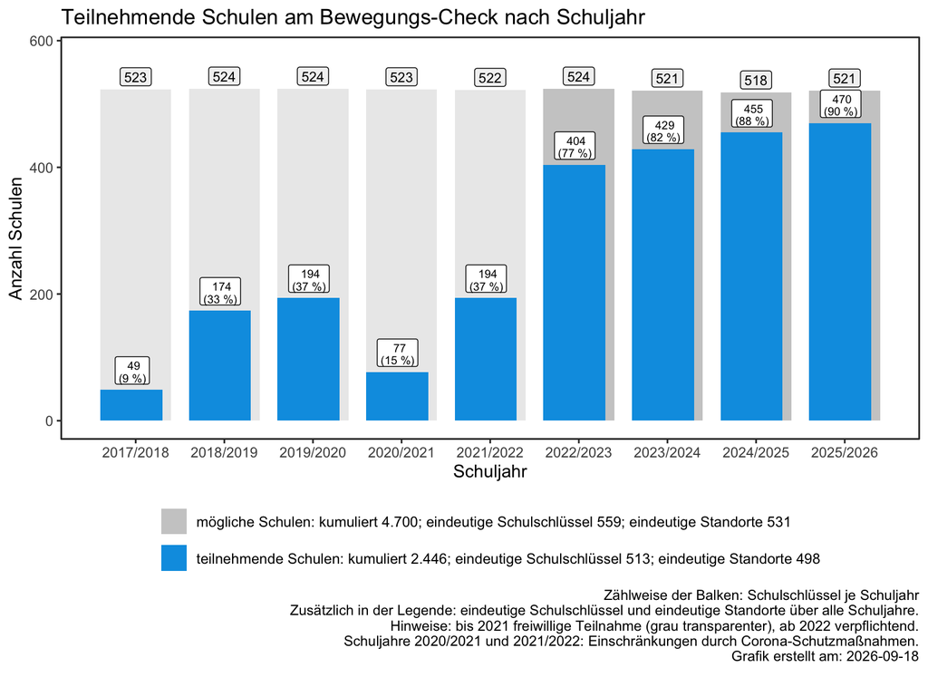

Abbildung 2: Mögliche und teilnehmende Schulen im BeKiGeKi-Bewegungs-Check nach Schuljahr. Die Balken zählen Schulschlüssel je Schuljahr. Eine Schule gilt als teilnehmend, wenn mindestens ein Fall mit Kerndaten und mindestens einem dokumentierten motorischen Testwert vorliegt. Die Legende weist zusätzlich die über alle dargestellten Schuljahre eindeutigen Schulschlüssel und Schul-Hauptstandorte aus.

Die Balken visualisieren für jedes Schuljahr die Anzahl eindeutiger **Schulnummern**. Ein Schulnummer kann sich im Zeitverlauf ändern, obwohl der **Schul-Hauptstandort** derselbe bleibt, etwa infolge einer Änderung der Schulart. Umgekehrt können einer Schulnummer über die Jahre mehrere Schul-Hauptstandorte zugeordnet sein, etwa wenn eine Schule umzieht. Deshalb weist die Legende neben der über die Schuljahre kumulierten Teilnahme-Anzahl auch die Zahl eindeutiger Schulnummern sowie die Zahl eindeutiger Schul-Hauptstandorte über alle dargestellten Schuljahre aus.

Eine Schule kann sich über *mehrere Schulteil-Standorte* verteilen. Für die Standortzählung wird jedoch jeweils nur der Schul-Hauptstandort berücksichtigt. Dieser wurde anhand von Geokoordinaten festgelegt. Eine Änderung der in Verwaltungsdaten geführten Schuladresse führt daher nicht zwangsläufig zu einem neuen Standort: Bleiben die Geokoordinaten unverändert, wird die Schule weiterhin demselben Schul-Hauptstandort zugeordnet. Umgekehrt kann eine Änderung der Geokoordinaten auf einen tatsächlichen Umzug oder auf eine nachträgliche Korrektur der Georeferenzierung zurückgehen. Die Zahl eindeutiger **Schul-Hauptstandorte ist somit eine geographisch definierte, nicht ausschließlich adressbasierte Zählung**.

Aktuell ist die Zahl eindeutiger Schul-Hauptstandorte geringer als die Zahl eindeutiger Schulnummern. Dies kann darauf hindeuten, dass sich mehrere Schulen einen Hauptstandort teilen. Es kann aber auch daraus resultieren, dass Schulnummern im Zeitverlauf geändert (Inflation von Schulnummern), Schulen geschlossen (Wegfall eines Schul-Hauptstandortes) oder zusammengelegt wurden (vormals Schul-Hauptstandort wird zu Schulteilstandort).

Die Schulstandort-, Schulteilstandort und Schulnummernhistorie kann in den interaktiven Dashboards [Schulstandorte](https://bekigeki.github.io/dashboards/d001/index.html) und [Schulnummern](https://bekigeki.github.io/dashboards/d002/index.html) erkundet werden.

## Methodische Hinweise

- Die Abbildungen beziehen sich auf Schulen in Thüringen und verwenden damit einen Raumbezug über den Schulstandort, nicht über den Wohnort der Kinder.
- Ein fehlender Messwert lässt nicht erkennen, ob ein Test nicht durchgeführt, nicht dokumentiert oder nicht übermittelt wurde. Die Zahl der dokumentierten Fälle ist daher eine konservative Beschreibung der in der Datenbasis sichtbaren Teilnahme.
- Die Zuordnung zur Zielgruppe „Drittklässler“ erfolgte vor Ort durch die Lehrkräfte in der Regel anhand des Jahrgangs beziehungsweise der tatsächlich besuchten Klassenstufe. Für die Datenaufbereitung kann ergänzend eine altersbasierte Zuordnung zum gesetzlichen [Stichtag] erfolgen („Drittklässler nach Alter“). Beide Zuordnungen sind nicht in jedem Fall identisch, etwa bei vorzeitiger Einschulung, Zurückstellung, Wiederholung einer Klassenstufe oder Überspringen einer Klassenstufe.

**HinweisAktualisierungen**

- 2026-08-24: Aktualisierung auf den aufbereiteten BeKi-Datenstand; Überarbeitung der Darstellung möglicher und erfasster Fälle sowie Ergänzung der Schulabbildung.
- 2026-03-17: Neue Daten für das Schuljahr 2025/2026; mögliche Teilnehmer aus `schulstatistik-thueringen.de`; Überarbeitung der Teilnehmerberechnung aller Jahre.
- 2025-02-19: Neue Daten für das Schuljahr 2024/2025.
- 2024-08-27: Weitere Schulen ergänzt.
- 2024-04-21: Weitere Schulen ergänzt.
- 2024-04-02: Daten der Schule 45420 ergänzt.
- 2024-03-25: Einbeziehung von Datensätzen ohne Geburtsdatumsangabe bei vorhandenen sportmotorischen Testdaten.
- 2024-02-28: Neue Daten für das Schuljahr 2023/2024; Korrektur um 16 Schüler im Jahr 2022 aufgrund eines Schulduplikats.
- 2023-05-15: Ergänzung der Hinweise zu jahrgangsübergreifend nicht eindeutigen Personen, Corona-Schutzmaßnahmen sowie freiwilliger und verpflichtender Teilnahme.
- 2023-05-05: Aktualisierung nach Eingang weiterer Datensätze; Ausschluss von Fällen ohne dokumentiertes motorisches Testergebnis.
- 2023-04-24: Aktualisierung nach Eingang weiterer Datensätze.
- 2023-03-09: Erstellung der Seite.

**HinweisKI-Hinweis**

Auswahl, Inhalte und Schlussredaktion menschlich; Entwurfshilfen KI. Verwendetes System: Perplexity AI, generatives KI-Sprachmodell; konkretes zugrunde liegendes Modell nicht ausgewiesen.